# Chine

Clémence Bracq

2024-04-15

# Pourquoi les immigrés originaires de Chine ressort-ils comme spécifiques?

## Spécificités des immigrés originaires de Chine au regard de l’accès aux soins

Origine qui recourt le moins au frottis : 32 % de femmes de plus de 25 ans immigrées d’origine chinoise n’ont pas eu de frottis dans les 3 dernières années, contre 24% en moyenne sur les immigrées toutes origines confondues et 16.5% dans la ppopulation non immigrée ni originaire d’Outre-mer et descendant de deux parents non immigrés et non originaires d’Outre-mer.

NB : Immigrées originaires de chine de plus de 25 ans : 347 enquêtées

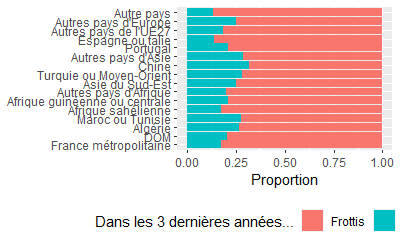

Même constat pour le gynécologue (cette fois sur toutes les femmes quelque soit leur âge) : origine qui recours le moins 61% des femmes immigrées originaires de Chine n’ont pas consulté le gynécologue dans l’année, contre 49% en moyenne parmi les immigrées toutes origines confondues et 47% parmi la population non immigrée ni originaire d’Outre-mer et descendant de deux parents non immigrés et non originaires d’Outre-mer. C’est également vrai si on restreint la population aux plus de 25 ans pour pouvoir comparer avec les résultats sur le frottis.

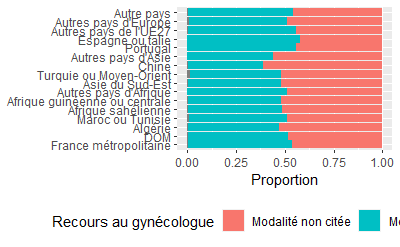

En fait, parmi les immigrés, c’est l’origine qui recourt le moins globalement : 13.4% des immigrés originaires de Chine n’ont pas recouru à un professionnel de santé dans les 12 derniers mois, contre 6% en moyenne des immigrés et 5% de la population non immigrée ni originaire d’Outre-mer et descendant de deux parents non immigrés et non originaires d’Outre-mer.

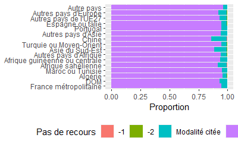

```r
ggsurvey(indiv_pd) +
  aes(x = originegeo_rec, fill = s_medeciq_g) +
  geom_bar(position = "fill") +
  scale_fill_hue(direction = 1) +
  labs(
    x = NULL,
    y = "Proportion",
    fill = "Pas de recours"
  ) +
  coord_flip() +
  theme(legend.position = "bottom")
```

C’est vrai pour toutes les spécialités, mais particulièrement pour la modalité “autre spécialité” : ils ne sont que 11% a avoir recouru à un autre type de spécialiste que dentiste ophtalmo psychiatre gynéco, contre 22,4% des immigrés toutes origines confondues et 30 % de la population non immigrée ni originaire d’Outre-mer et descendant de deux parents non immigrés et non originaires d’Outre-mer.

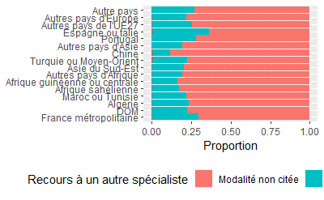

Ils renoncent moins souvent aux soins que la population née en France métropolitaine et que plusieurs autres origines d’immigrés.

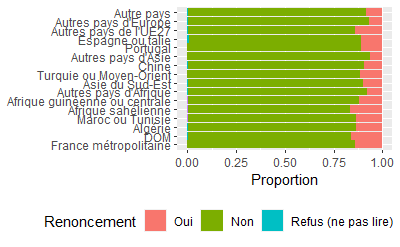

Ils sont plutôt en bonne santé par rapport à d’autres origines, mais de manière comparable à la population née en France métropolitaine ou aux immigrés d’Afrique subsaharienne.

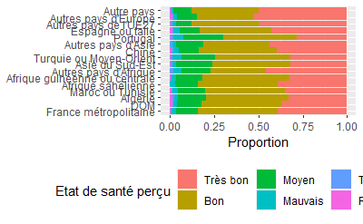

## Quel facteur explicatif?

### Les discriminations?

Les immigrés originaires de Chine ne déclarent pas plus de discriminations par les professionnels de santé que les autres : ils sont 3.7% à en déclarer, contre 5.5% dans la population née en France métropolitaine et 10% des immigrés originaires d’Afrique sahélienne.

### La couverture sociale?

Ils ne sont pas non plus moins bien couverts :

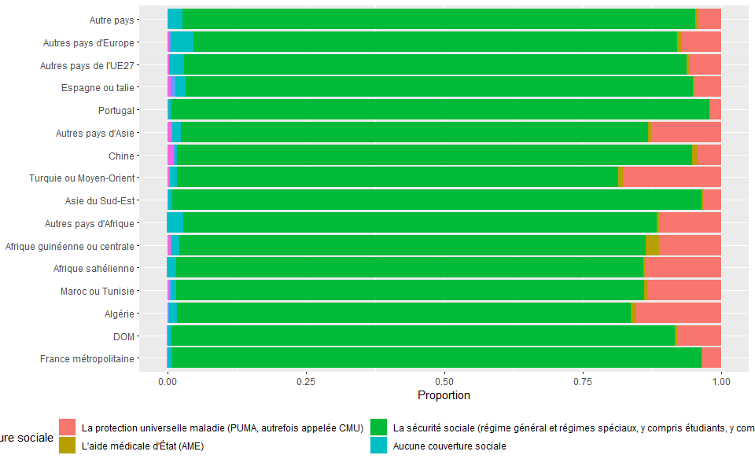

### La langue?

Les immigrés originaires de Chine sont ceux qui ont le plus de difficultés avec le français, suivis des autres immigrés originaires d’Asie.

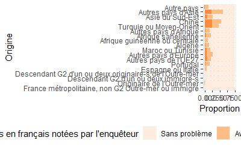

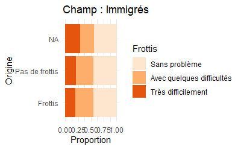

Ces résultats cachent une grande hétérogénéité entre les origines : on compare ici Turquie Moyen Orient, Autres pays d’Asie et Chine (les origines avec la plus faible maîtrise du français).

Ches les immigrés originaires de Chine c’est le contraire, ça semble avoir plutôt un impact sur le recours au généraliste (5 points de pourcentage) qu’au frottis.

[figure not shown]

Les immigrés originaires de Chine semblent ainsi également atypique sur l’effet de la langue sur le recours.

### Effet de l’état de santé

Au-delà du relativement bon état de santé des immigrés originaires de Chine, cet état de santé semble avoir plus d’effet sur leur absence de recours que sur le reste de la population (pas de recours préventif?).

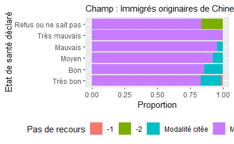

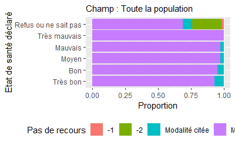

### Communauté?

Derrière ça on pense peut-être aux médecins traditionnelles? On utilise une question sur l’origine des amis pour essayer de voir ça Les immigrés originaires de Chine sont parmi les immigrés ceux qui ont le plus d’amis de la même origine qu’eux.

```r
indiv_chine<- indiv %>% filter(originegeo_rec=="Chine") %>% #594
  filter(s_medeciq_flag == "A répondu")
indiv_chine_pd <-svydesign(ids = indiv_chine$ident_fa, data = indiv_chine, weights = indiv_chine$poidsi)
indiv_mo<- indiv %>% filter(originegeo_rec=="Turquie ou Moyen-Orient") %>% #594
  filter(s_medeciq_flag == "A répondu")
indiv_mo_pd <-svydesign(ids = indiv_mo$ident_fa, data = indiv_mo, weights = indiv_mo$poidsi)
```

[figure not shown]

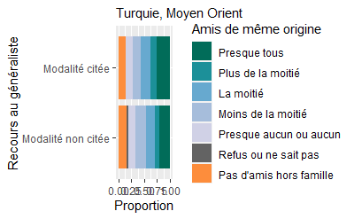

### Profession

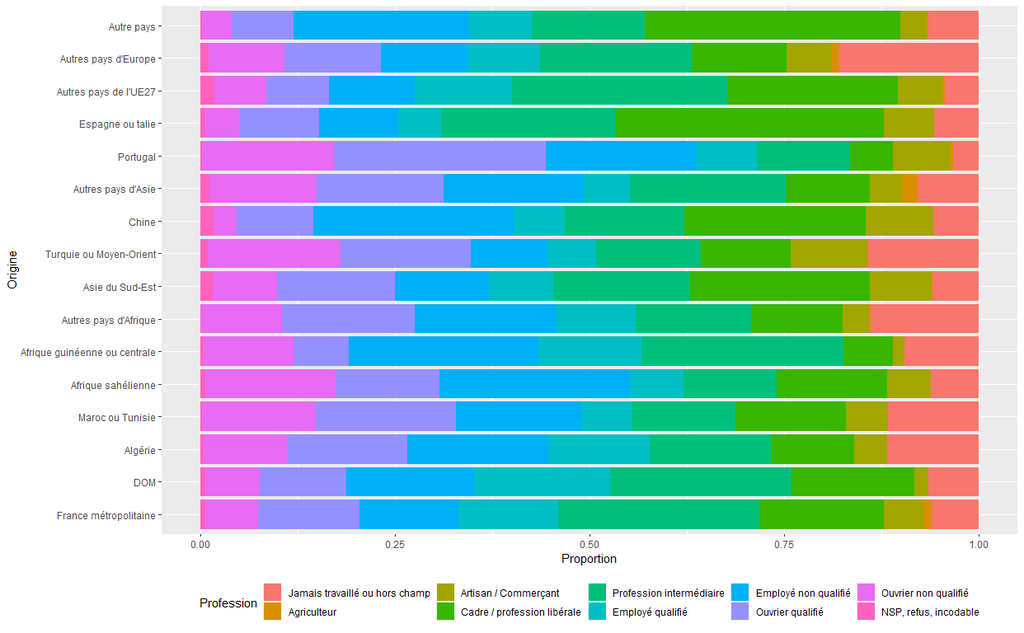

Beaucoup d’employés non qualifiés parmi les immigrés originaires de chine

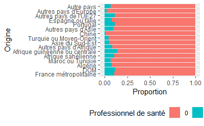

### Effet naissances pour frottis

le fait d’avoir des enfants a beaucoup moins d’effet sur le recours au frottis des immigrées originaires de Chine que sur toute la population : sur toute la population on passe de 24% à 7% de personnes qui ont pas de frottis, pour les immigrées originaires de chine on passe de 35.4% à 26.5%. Alors que pour les immigrées originaires de Turquie ou du Moyen Orient très gros effet

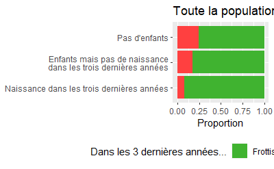

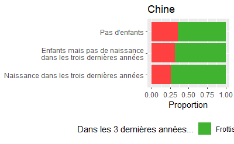

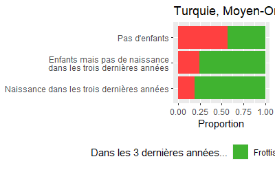

### Effet âge pour frottis

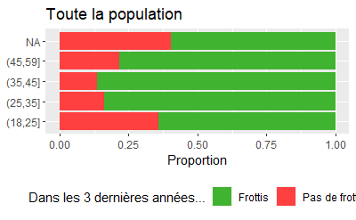

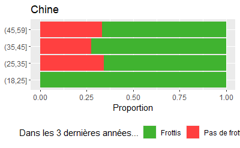

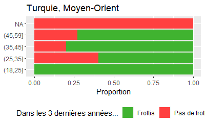

### Effet couple pour frottis

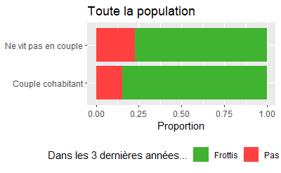

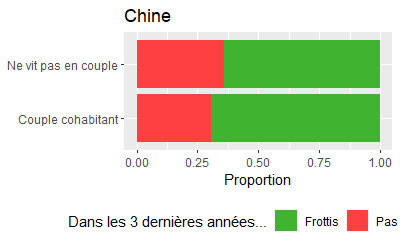

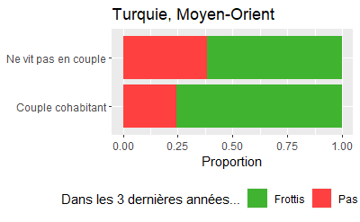

### Lien ségrégation/accès?

[figure not shown]

### Faire un point sur Turquie MO valeurs tradi pr frottis (femmes qui étudient peu etc…)

#### Régression

```r
indiv_chine_frott_pd <-svydesign(ids = indiv_chine_frott$ident_fa, data = indiv_chine_frott, weights = indiv_chine_frott$poidsi)
```

[output not shown]

```r
modelg <- svyglm(as.factor(s_medeciq_g) ~
                  agenq+enfant+
                  s_etat_rec+
                  q_franc+
                  # s_traite_rec+
                  sexee +
                  # origine_tous_g2+
                   csnq_actif_rec+diplome+tr_revenu +
                   # covid+
                   couplee_rec #+
                  # enfant +
                  # durtotfrm +
                  # a_rfami+
                  # a_ramis+
                  # a_retud+
                  # a_rorig+
                  # a_rquart+
                  # tuu2017 +
                  # l_immi +
                  # iris_pct_sedent +
                  # iris_pct_immi
                ,family = quasibinomial,
                design = indiv_chine_pd)
```

[output not shown]

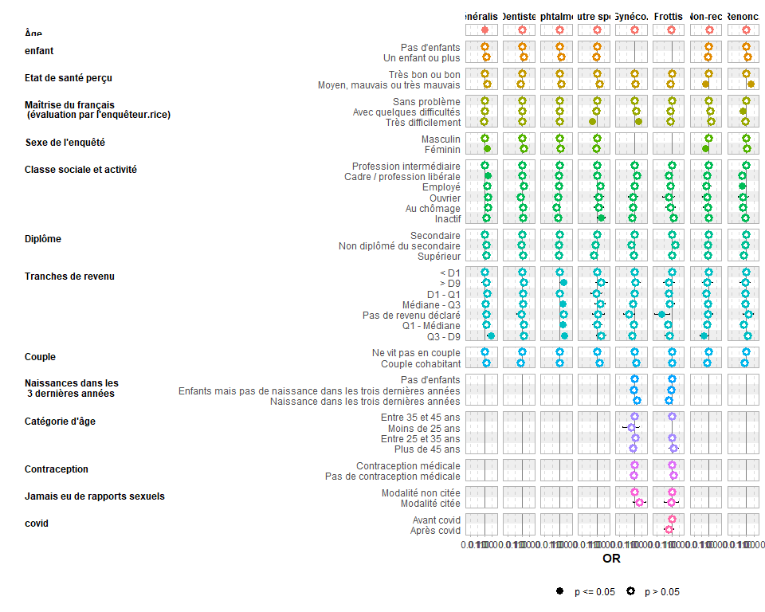

##### Avec comu

```r
modelg <- svyglm(as.factor(s_medeciq_g) ~
                  agenq+enfant+a_rorig_rec+
                  s_etat_rec+
                  q_franc+
                  # s_traite_rec+
                  sexee +
                  # origine_tous_g2+
                   csnq_actif_rec+diplome+tr_revenu +
                   # covid+
                   couplee_rec #+
                  # enfant +
                  # durtotfrm +
                  # a_rfami+
                  # a_ramis+
                  # a_retud+
                  # a_rorig+
                  # a_rquart+
                  # tuu2017 +
                  # l_immi +
                  # iris_pct_sedent +
                  # iris_pct_immi
                ,family = quasibinomial,
                design = indiv_chine_pd)
```

##### Avec segreg

```r
modelg <- svyglm(as.factor(s_medeciq_g) ~
                  agenq+enfant+iris_pct_imchi_cat+
                  s_etat_rec+
                  q_franc+
                  # s_traite_rec+
                  sexee +
                  # origine_tous_g2+
                   csnq_actif_rec+diplome+tr_revenu +
                   # covid+
                   couplee_rec #+
                  # enfant +
                  # durtotfrm +
                  # a_rfami+
                  # a_ramis+
                  # a_retud+
                  # a_rorig+
                  # a_rquart+
                  # tuu2017 +
                  # l_immi +
                  # iris_pct_sedent +
                  # iris_pct_immi
                ,family = quasibinomial,
                design = indiv_chine_pd)
```

[output not shown]

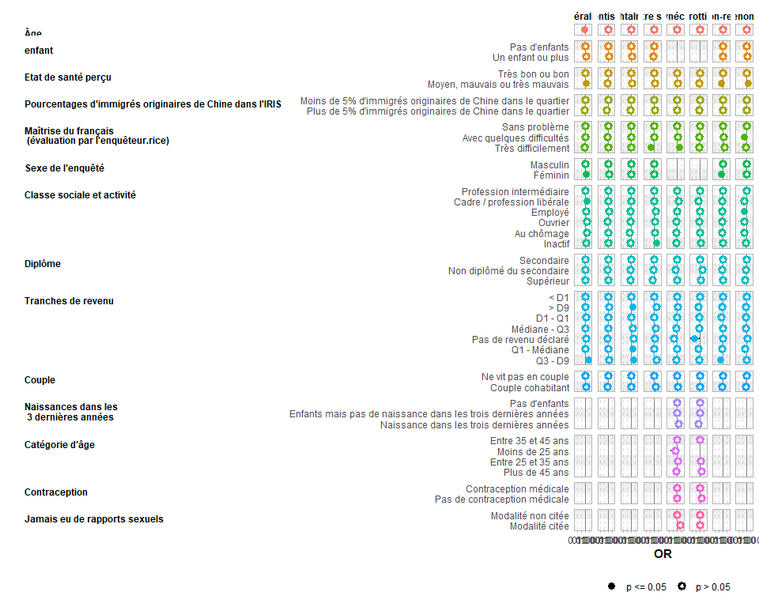